# Subsetting Data in R

## Recap

- Use `<-` to save (assign) values to objects
- Need to assign the output of the function to keep the result!
- Functions (like verbs) perform specific tasks in R and are found within **packages**
- Use `c()` to combine elements in a vectors
- `length()`, `class()`, and `str()` tell you information about an object
- Install packages with `install.packages()`
- Load packages with `library()`
- Get help with `?` or help pane
- `readr`has helpful functions like `read_csv()` that can help you import data into R like so: `df_example_readr <- read_csv(file = "documents/data_analysis/data_file.csv")` 📃[Cheatsheet](https://jhudatascience.org/intro_to_r/modules/cheatsheets/Day-2.pdf)

## recap continued

```r
head(iris)
```

```
  Sepal.Length Sepal.Width Petal.Length Petal.Width Species
1          5.1         3.5          1.4         0.2  setosa
2          4.9         3.0          1.4         0.2  setosa
3          4.7         3.2          1.3         0.2  setosa
4          4.6         3.1          1.5         0.2  setosa
5          5.0         3.6          1.4         0.2  setosa
6          5.4         3.9          1.7         0.4  setosa
```

## `summarize()` or `summarise()`

These functions are the same (just language preference).

- It creates a new dataframe with stats about the data.
- The columns are named whatever you want.
- It allows us to apply mathematical functions on columns of a dataframe and make a new dataframe with just that information.

`Data %>% summarize(any_name = math_function(column))`

```r
iris %>% summarize(Mean_Petal_Length = mean(Petal.Length))
```

```
  Mean_Petal_Length
1             3.758
```

## `group_by()`

It sets up your code so that all subsequent steps will parse the data based on what you use in group_by.

```r
iris %>% group_by(Species) %>%
  summarize(Mean_Petal_Length = mean(Petal.Length))
```

```
# A tibble: 3 × 2
  Species    Mean_Petal_Length
  <fct>                  <dbl>
1 setosa                  1.46
2 versicolor              4.26
3 virginica               5.55
```

## Overview

In this module, we will show you how to:

1. Look at your data in different ways
2. Rename columns of a data frame
3. Subset rows of a data frame
4. Subset columns of a data frame
5. Add new columns to a data frame

## Setup

We will largely focus on the `dplyr` package which is part of the `tidyverse`.

Some resources on how to use `dplyr`:

- https://dplyr.tidyverse.org/
- https://cran.r-project.org/web/packages/dplyr/vignettes/dplyr.html
- https://www.opencasestudies.org/

## Loading in dplyr and tidyverse

See this website for a list of the packages included in the `tidyverse`: https://www.tidyverse.org/packages/

```r
library(tidyverse) # loads dplyr and other packages!
```

## Getting data to work with

We can take a look at the top of it by using the `head()` function.

```r
state_data <-read_csv("https://hutchdatascience.org/SeattleStatSummer_R/data/states.csv")
head(state_data)
```

```
# A tibble: 6 × 14
  entity     state_abb state_area_sq_mil… state_division state_region population
  <chr>      <chr>                  <dbl> <chr>          <chr>             <dbl>
1 Alabama    AL                     51609 East South Ce… South           4903185
2 Alaska     AK                    589757 Pacific        West             731545
3 Arizona    AZ                    113909 Mountain       West            7278717
4 Arkansas   AR                     53104 West South Ce… South           3017804
5 California CA                    158693 Pacific        West           39512223
6 Colorado   CO                    104247 Mountain       West            5758736
# … with 8 more variables: births_in_2021 <dbl>, fertility_rate_per_1000 <dbl>,
#   cesarean_percent <dbl>, life_expect <dbl>, cancer_rate_per_100000 <dbl>,
#   cancer_mortality <dbl>, Administered_Dose1_Pop_Pct <dbl>,
#   Series_Complete_Pop_Pct <dbl>
```

## To see the bottom of the data use `tail()`

```r
tail(state_data) # looking at the bottom 6 rows of the mtcars data
```

```
# A tibble: 6 × 14
  entity       state_abb state_area_sq_m… state_division state_region population
  <chr>        <chr>                <dbl> <chr>          <chr>             <dbl>
1 Washington   WA                   68192 Pacific        West            7614893
2 West Virgin… WV                   24181 South Atlantic South           1792147
3 Wisconsin    WI                   56154 East North Ce… North Centr…    5822434
4 Wyoming      WY                   97914 Mountain       West             578759
5 District of… DC                      68 South Atlantic South            705749
6 Puerto Rico  PR                    3515 <NA>           <NA>            3193694
# … with 8 more variables: births_in_2021 <dbl>, fertility_rate_per_1000 <dbl>,
#   cesarean_percent <dbl>, life_expect <dbl>, cancer_rate_per_100000 <dbl>,
#   cancer_mortality <dbl>, Administered_Dose1_Pop_Pct <dbl>,
#   Series_Complete_Pop_Pct <dbl>
```

## Checking the data: `glimpse()`

In addition to `head()` and `tail()`, the `glimpse()`function of the `dplyr` package is another great function to look at your data.

```r
glimpse(state_data)
```

```
Rows: 52
Columns: 14
$ entity                     <chr> "Alabama", "Alaska", "Arizona", "Arkansas",…
$ state_abb                  <chr> "AL", "AK", "AZ", "AR", "CA", "CO", "CT", "…
$ state_area_sq_miles        <dbl> 51609, 589757, 113909, 53104, 158693, 10424…
$ state_division             <chr> "East South Central", "Pacific", "Mountain"…
$ state_region               <chr> "South", "West", "West", "South", "West", "…
$ population                 <dbl> 4903185, 731545, 7278717, 3017804, 39512223…
$ births_in_2021             <dbl> 58054, 9367, 77916, 35965, 420608, 62949, 3…
$ fertility_rate_per_1000    <dbl> 59.5, 64.9, 55.5, 61.7, 52.8, 52.5, 52.1, 5…
$ cesarean_percent           <dbl> 35.1, 24.2, 28.7, 34.3, 30.8, 27.3, 35.4, 3…
$ life_expect                <dbl> 73.2, 76.6, 76.3, 73.8, 79.0, 78.3, 78.4, 7…
$ cancer_rate_per_100000     <dbl> 160.2, 156.0, 134.7, 168.2, 132.4, 126.5, 1…
$ cancer_mortality           <dbl> 10429, 1093, 12813, 6516, 59503, 8058, 6526…
$ Administered_Dose1_Pop_Pct <dbl> 64.8, 72.8, 77.1, 69.6, 84.3, 83.3, 95.0, 8…
$ Series_Complete_Pop_Pct    <dbl> 53.0, 64.9, 65.8, 56.7, 74.4, 73.2, 82.8, 7…
```

## Dimensions

`nrow` gives the number of rows

```r
nrow(state_data)
```

```
[1] 52
```

## Renaming Columns of a data frame or tibble

To rename columns in `dplyr`, you can use the `rename` function.

Notice the **new name** is listed **first**!

```r
# general format! not code!
{data you are creating or changing} <- {data you are using} %>%
                            rename({New Name} = {Old name})
```

```r
state_data_rename <- state_data %>% rename(location = entity)
head(state_data_rename)
```

```
# A tibble: 6 × 14
  location   state_abb state_area_sq_mil… state_division state_region population
  <chr>      <chr>                  <dbl> <chr>          <chr>             <dbl>
1 Alabama    AL                     51609 East South Ce… South           4903185
2 Alaska     AK                    589757 Pacific        West             731545
3 Arizona    AZ                    113909 Mountain       West            7278717
4 Arkansas   AR                     53104 West South Ce… South           3017804
5 California CA                    158693 Pacific        West           39512223
6 Colorado   CO                    104247 Mountain       West            5758736
# … with 8 more variables: births_in_2021 <dbl>, fertility_rate_per_1000 <dbl>,
#   cesarean_percent <dbl>, life_expect <dbl>, cancer_rate_per_100000 <dbl>,
#   cancer_mortality <dbl>, Administered_Dose1_Pop_Pct <dbl>,
#   Series_Complete_Pop_Pct <dbl>
```

## Reassign the data!

If we don’t reassign the data it will just print the change to the screen

```r
# this does not change the data! Just prints the result
state_data %>% rename(location = entity)

# this makes a new data frame that is changed
state_data_rename <- state_data %>% rename(location = entity)

# this updates the existing data
state_data <- state_data %>% rename(location = entity)
```

## Unusual Column Names

It’s best to avoid unusual column names where possible, as things get tricky later.

You can use ` backticks` to refer to them . You may see people use quotes in certain situations.

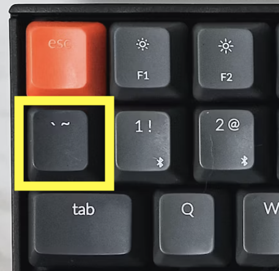

Atypical column names are those with:

- spaces
- number without characters
- number starting the name
- other punctuation marks (besides “_” or “.” and not at the beginning)

## A solution!

Rename tricky column names so that you don’t have to deal with them later!

[figure not shown]

## Summary

- `head()`, `tail()`, and `glimpse()` help us look at the data
- the `rename()` function of `dplyr` can help you rename columns
- avoid using punctuation in column names
- if you must refer to a nonstandard column name - use backticks around it.

## Let’s practice!

## Practice

How can you look at the last row of a data frame?

```r
state_data %>% ____
```

## Practice

How can you see the data rotated to see the column names more easily?

```r
state_data %>% ______
```

## Practice

How can you rename the column “state_region” to be “region”?

```r
state_data %>% rename(______________ = ______)
```

## Subsetting Columns

## Subset columns of a data frame: dplyr

The `select` command from `dplyr` allows you to subset part of the data

```r
state_data %>% select(cancer_mortality)
```

```
# A tibble: 52 × 1
   cancer_mortality
              <dbl>
 1            10429
 2             1093
 3            12813
 4             6516
 5            59503
 6             8058
 7             6526
 8             2178
 9            46937
10            18136
# … with 42 more rows
```

## Select multiple columns

We can use `select` to select for multiple columns.

```r
state_data %>% select(entity, cancer_mortality)
```

```
# A tibble: 52 × 2
   entity      cancer_mortality
   <chr>                  <dbl>
 1 Alabama                10429
 2 Alaska                  1093
 3 Arizona                12813
 4 Arkansas                6516
 5 California             59503
 6 Colorado                8058
 7 Connecticut             6526
 8 Delaware                2178
 9 Florida                46937
10 Georgia                18136
# … with 42 more rows
```

## See the Select “helpers”

Here are a few:

```r
last_col()
starts_with()
ends_with()
contains() # like searching
```

Type `tidyselect::` in the **console** and see what RStudio suggests:

[figure not shown]

## Select columns of a data frame: dplyr

The `select` command from `dplyr` allows you to subset columns matching patterns:

```r
state_data %>% select(starts_with("cancer"))
```

```
# A tibble: 52 × 2
   cancer_rate_per_100000 cancer_mortality
                    <dbl>            <dbl>
 1                   160.            10429
 2                   156              1093
 3                   135.            12813
 4                   168.             6516
 5                   132.            59503
 6                   126.             8058
 7                   134.             6526
 8                   153.             2178
 9                   142.            46937
10                   152.            18136
# … with 42 more rows
```

## Combining tidyselect helpers with regular selection

```r
state_data %>% select(entity, starts_with("cancer"))
```

```
# A tibble: 52 × 3
   entity      cancer_rate_per_100000 cancer_mortality
   <chr>                        <dbl>            <dbl>
 1 Alabama                       160.            10429
 2 Alaska                        156              1093
 3 Arizona                       135.            12813
 4 Arkansas                      168.             6516
 5 California                    132.            59503
 6 Colorado                      126.             8058
 7 Connecticut                   134.             6526
 8 Delaware                      153.             2178
 9 Florida                       142.            46937
10 Georgia                       152.            18136
# … with 42 more rows
```

## Sometimes we want to preview the values

We can use `pull()` for that to “pull out” the values. This can give us a sense of the range, missing values, unusual values etc.

```r
state_data %>% pull(cancer_rate_per_100000)
```

```
 [1] 160.2 156.0 134.7 168.2 132.4 126.5 133.5 153.2 141.6 151.5 125.4 140.4
[13] 150.0 169.7 150.9 150.8 181.1 163.9 161.3 139.2 137.4 160.1 143.2 181.8
[25] 164.2 142.2 150.9 143.2 145.7 130.6 137.3 125.3 153.6 137.8 163.0 175.1
[37] 155.2 152.9 142.0 155.2 154.8 166.3 143.3 121.0 154.0 150.5 149.3 184.7
[49] 147.2 156.7    NA    NA
```

## Practice

How can you subset the data to just have the “entity” and “fertility_rate_per_1000” columns?

```r
state_data %>% ______(______, _____________________)
```

## Practice

How can I subset the data to just have the “entity” and “fertility_rate_per_1000” columns?

```r
state_data %>% ______(______, _____________________)
```

## Subsetting Rows

## Subset rows of a data frame: dplyr

The command in `dplyr` for subsetting rows is `filter`.

```r
# General format - Not the code!
{data object to update} <- {data to use} %>%
                        filter({variable name} {some condition})
```

```r
state_data %>% filter(cancer_rate_per_100000 < 130)
```

```
# A tibble: 4 × 14
  entity   state_abb state_area_sq_miles state_division  state_region population
  <chr>    <chr>                   <dbl> <chr>           <chr>             <dbl>
1 Colorado CO                     104247 Mountain        West            5758736
2 Hawaii   HI                       6450 Pacific         West            1415872
3 New York NY                      49576 Middle Atlantic Northeast      19453561
4 Utah     UT                      84916 Mountain        West            3205958
# … with 8 more variables: births_in_2021 <dbl>, fertility_rate_per_1000 <dbl>,
#   cesarean_percent <dbl>, life_expect <dbl>, cancer_rate_per_100000 <dbl>,
#   cancer_mortality <dbl>, Administered_Dose1_Pop_Pct <dbl>,
#   Series_Complete_Pop_Pct <dbl>
```

## Subset rows of a data frame: dplyr

You can have multiple **conditions** using the following:

- `==` : equals to
- `!=`: not equal to (`!` : not/negation)
- `>` / `<`: greater than / less than
- `>=` or `<=`: greater than or equal to / less than or equal to
- `&` : AND
- `|` : OR

## Subset rows of a data frame: dplyr

You can filter by two conditions using `&` (must meet both conditions):

```r
state_data %>% filter(cancer_rate_per_100000 < 130 & population > 4000000)
```

```
# A tibble: 2 × 14
  entity   state_abb state_area_sq_miles state_division  state_region population
  <chr>    <chr>                   <dbl> <chr>           <chr>             <dbl>
1 Colorado CO                     104247 Mountain        West            5758736
2 New York NY                      49576 Middle Atlantic Northeast      19453561
# … with 8 more variables: births_in_2021 <dbl>, fertility_rate_per_1000 <dbl>,
#   cesarean_percent <dbl>, life_expect <dbl>, cancer_rate_per_100000 <dbl>,
#   cancer_mortality <dbl>, Administered_Dose1_Pop_Pct <dbl>,
#   Series_Complete_Pop_Pct <dbl>
```

## Subset rows of a data frame: dplyr

If you want OR statements (meaning the data can meet either condition does not need to meet both), you need to use `|` between conditions:

```r
state_data %>% filter(cancer_rate_per_100000 < 130 | population > 20000000)
```

```
# A tibble: 7 × 14
  entity     state_abb state_area_sq_mil… state_division state_region population
  <chr>      <chr>                  <dbl> <chr>          <chr>             <dbl>
1 California CA                    158693 Pacific        West           39512223
2 Colorado   CO                    104247 Mountain       West            5758736
3 Florida    FL                     58560 South Atlantic South          21477737
4 Hawaii     HI                      6450 Pacific        West            1415872
5 New York   NY                     49576 Middle Atlant… Northeast      19453561
6 Texas      TX                    267339 West South Ce… South          28995881
7 Utah       UT                     84916 Mountain       West            3205958
# … with 8 more variables: births_in_2021 <dbl>, fertility_rate_per_1000 <dbl>,
#   cesarean_percent <dbl>, life_expect <dbl>, cancer_rate_per_100000 <dbl>,
#   cancer_mortality <dbl>, Administered_Dose1_Pop_Pct <dbl>,
#   Series_Complete_Pop_Pct <dbl>
```

## Be careful with column names and `filter`

This will not work the way you might expect! Best to stick with nothing but the column name if it is a typical name. Use backticks if it isn’t typical.

```r
state_data %>% filter("cancer_rate_per_100000"< 130)
```

```
# A tibble: 0 × 14
# … with 14 variables: entity <chr>, state_abb <chr>,
#   state_area_sq_miles <dbl>, state_division <chr>, state_region <chr>,
#   population <dbl>, births_in_2021 <dbl>, fertility_rate_per_1000 <dbl>,
#   cesarean_percent <dbl>, life_expect <dbl>, cancer_rate_per_100000 <dbl>,
#   cancer_mortality <dbl>, Administered_Dose1_Pop_Pct <dbl>,
#   Series_Complete_Pop_Pct <dbl>
```

## Always good to check each step!

Did the filter work the way you expected? Did the number of rows change? Use `nrow`!

[figure not shown]

https://media.giphy.com/media/5b5OU7aUekfdSAER5I/giphy.gif

## Summary

- `pull()` to get values out of a data frame
- `select()` creates a smaller data frame with only certain columns
- you can `select()` based on patterns in the column names using tidyselect functions
- you can combine multiple tidyselect functions together like `select(starts_with("C"), ends_with("state"))`
- `filter()` can be used to filter out rows based on logical conditions
- avoid using quotes when referring to column names with `filter()`

## Summary Continued

- `==` is the same as equivalent to
- `&` means both conditions must be met to remain after `filter()`
- `|` means either conditions needs to be met to remain after `filter()`

🏠 [Workshop Website](https://hutchdatascience.org/SeattleStatSummer_R/)

## Practice

How can I filter the data to only see the row about the state of California

```r
state_data %>% filter(______ __ __________)
```

## Adding/Modifying Columns

## Adding columns to a data frame: dplyr (`tidyverse` way)

The `mutate` function in `dplyr` allows you to add or modify columns of a data frame.

```r
# General format - Not the code!
{data object to update} <- {data to use} %>%
                      mutate({new variable name} = {new variable source})
```

```r
state_updated <- state_data %>%
                mutate(newcol = cancer_mortality / population)
```

## Let’s take a look

```r
glimpse(state_updated)
```

```
Rows: 52
Columns: 15
$ entity                     <chr> "Alabama", "Alaska", "Arizona", "Arkansas",…
$ state_abb                  <chr> "AL", "AK", "AZ", "AR", "CA", "CO", "CT", "…
$ state_area_sq_miles        <dbl> 51609, 589757, 113909, 53104, 158693, 10424…
$ state_division             <chr> "East South Central", "Pacific", "Mountain"…
$ state_region               <chr> "South", "West", "West", "South", "West", "…
$ population                 <dbl> 4903185, 731545, 7278717, 3017804, 39512223…
$ births_in_2021             <dbl> 58054, 9367, 77916, 35965, 420608, 62949, 3…
$ fertility_rate_per_1000    <dbl> 59.5, 64.9, 55.5, 61.7, 52.8, 52.5, 52.1, 5…
$ cesarean_percent           <dbl> 35.1, 24.2, 28.7, 34.3, 30.8, 27.3, 35.4, 3…
$ life_expect                <dbl> 73.2, 76.6, 76.3, 73.8, 79.0, 78.3, 78.4, 7…
$ cancer_rate_per_100000     <dbl> 160.2, 156.0, 134.7, 168.2, 132.4, 126.5, 1…
$ cancer_mortality           <dbl> 10429, 1093, 12813, 6516, 59503, 8058, 6526…
$ Administered_Dose1_Pop_Pct <dbl> 64.8, 72.8, 77.1, 69.6, 84.3, 83.3, 95.0, 8…
$ Series_Complete_Pop_Pct    <dbl> 53.0, 64.9, 65.8, 56.7, 74.4, 73.2, 82.8, 7…
$ newcol                     <dbl> 0.002126985, 0.001494098, 0.001760338, 0.00…
```

## Use mutate to modify existing columns

The `mutate` function in `dplyr` allows you to add or modify columns of a data frame.

```r
# General format - Not the code!
{data object to update} <- {data to use} %>%
                mutate({variable name to change} = {variable modification})
```

```r
state_updated<- state_updated %>%
              mutate(newcol = newcol *1000000)
```

## Let’s take a look

```r
glimpse(state_updated)
```

```
Rows: 52
Columns: 15
$ entity                     <chr> "Alabama", "Alaska", "Arizona", "Arkansas",…
$ state_abb                  <chr> "AL", "AK", "AZ", "AR", "CA", "CO", "CT", "…
$ state_area_sq_miles        <dbl> 51609, 589757, 113909, 53104, 158693, 10424…
$ state_division             <chr> "East South Central", "Pacific", "Mountain"…
$ state_region               <chr> "South", "West", "West", "South", "West", "…
$ population                 <dbl> 4903185, 731545, 7278717, 3017804, 39512223…
$ births_in_2021             <dbl> 58054, 9367, 77916, 35965, 420608, 62949, 3…
$ fertility_rate_per_1000    <dbl> 59.5, 64.9, 55.5, 61.7, 52.8, 52.5, 52.1, 5…
$ cesarean_percent           <dbl> 35.1, 24.2, 28.7, 34.3, 30.8, 27.3, 35.4, 3…
$ life_expect                <dbl> 73.2, 76.6, 76.3, 73.8, 79.0, 78.3, 78.4, 7…
$ cancer_rate_per_100000     <dbl> 160.2, 156.0, 134.7, 168.2, 132.4, 126.5, 1…
$ cancer_mortality           <dbl> 10429, 1093, 12813, 6516, 59503, 8058, 6526…
$ Administered_Dose1_Pop_Pct <dbl> 64.8, 72.8, 77.1, 69.6, 84.3, 83.3, 95.0, 8…
$ Series_Complete_Pop_Pct    <dbl> 53.0, 64.9, 65.8, 56.7, 74.4, 73.2, 82.8, 7…
$ newcol                     <dbl> 2126.985, 1494.098, 1760.338, 2159.186, 150…
```

## Let’s rename the new column

```r
state_updated<- state_updated %>%
              rename(cancer_mortality_rate_per_1000000 = newcol)
```

## Reordering rows

The `arrange()` function can be a big help! It automatically does it in smallest to largest order.

```r
state_updated %>% arrange(cancer_mortality_rate_per_1000000)
```

```
# A tibble: 52 × 15
   entity      state_abb state_area_sq_m… state_division state_region population
   <chr>       <chr>                <dbl> <chr>          <chr>             <dbl>
 1 Utah        UT                   84916 Mountain       West            3205958
 2 Colorado    CO                  104247 Mountain       West            5758736
 3 Texas       TX                  267339 West South Ce… South          28995881
 4 Alaska      AK                  589757 Pacific        West             731545
 5 California  CA                  158693 Pacific        West           39512223
 6 New York    NY                   49576 Middle Atlant… Northeast      19453561
 7 North Dako… ND                   70665 West North Ce… North Centr…     762062
 8 Georgia     GA                   58876 South Atlantic South          10617423
 9 Nevada      NV                  110540 Mountain       West            3080156
10 New Jersey  NJ                    7836 Middle Atlant… Northeast       8882190
# … with 42 more rows, and 9 more variables: births_in_2021 <dbl>,
#   fertility_rate_per_1000 <dbl>, cesarean_percent <dbl>, life_expect <dbl>,
#   cancer_rate_per_100000 <dbl>, cancer_mortality <dbl>,
#   Administered_Dose1_Pop_Pct <dbl>, Series_Complete_Pop_Pct <dbl>,
#   cancer_mortality_rate_per_1000000 <dbl>
```

## A note about base R:

The `$` operator is similar to `pull()`. This is the base R way to do this:

```r
mtcars$carb
```

```
 [1] 4 4 1 1 2 1 4 2 2 4 4 3 3 3 4 4 4 1 2 1 1 2 2 4 2 1 2 2 4 6 8 2
```

Although it is easier (for this one task), mixing and matching the `$` operator with tidyverse functions usually doesn’t work. Therefore, we want to let you know about it in case you see it, but we suggest that you try working with the tidyverse way.

## Practice

How can you create a new column that is the `fertility_rate_per_1000` multiplied by 2?

```r
state_data %>% mutate(______ = _____________________ *2)
```

How can you modify the column that you just made to divide it by the `population` value?

```r
state_data %>% mutate(______ = ______ / ___________)
```

## Summary

- can subset or remove rows with `filter()`
- can subset or remove (select what we want to keep) columns with `select()`
- `mutate()` can be used to create new variables or modify them

```r
# General format - Not the code!
{data object to update} <- {data to use} %>%
                        mutate({new variable name} = {new variable source})
```

🏠 [Workshop Website](https://hutchdatascience.org/SeattleStatSummer_R/)